# Week 10: Regression, part 2

PS 812 - Introduction to Statistical Methods in Political Science

Anton Strezhnev

strezhnev@wisc.edu

University of Wisconsin-Madison

November 10, 2026

## Welcome back!

$$\newcommand{\Var}{\text{Var}}
\newcommand{\Cov}{\text{Cov}}
\newcommand{\Corr}{\text{Corr}}
\newcommand{\indep}{\mathrel{\perp\mkern-10mu\perp}}$$

## Ordinary Least Squares

## OLS for estimating the CEF

- We’ll show that under i.i.d. sampling, OLS is consistent for the **Best Linear Predictor**
  - The linear combination of $X_i$ that *minimizes* the mean squared prediction error.
- But we want to estimate the **CEF** $\mathbb{E}[Y_i \mid \mathbf{X}_i]$
  - When is OLS consistent for the **conditional expectation function**?
- When the **CEF** is the **BLP**!

  $$\mathbb{E}[Y_i \mid \mathbf{X}_i] = \mathbf{X}_i^\prime\boldsymbol{\beta}$$
- When is the CEF linear?
  - **Saturated** models: every covariate is discrete and there is a dummy for every combination of values (e.g. the three party categories)
  - Otherwise, linearity is an **assumption** about the functional form
  - Remember, this is *linearity in parameters* given a particular $\mathbf{X}$
    - Adding more terms to $\mathbf{X}$ may make linearity more plausible!

## Interpreting multiple regression coefficients

- With a **bivariate** regression, interpreting the coefficient on $X_i$ is straightforward

  $$\hat{\beta}_1 = \frac{\widehat{\Cov}(X_i, Y_i)}{\widehat{\Var}(X_i)}$$
- The difference in the expectation of $Y_i$ between respondents whose $X_i$ differs by **one unit**

  $$\begin{aligned}
  \mathbb{E}[Y_i \mid X_i = x + 1] - \mathbb{E}[Y_i \mid X_i = x] &= \big(\beta_0 + \beta_1 (x + 1)\big) - \big(\beta_0 + \beta_1 x\big) \\
  &= \beta_1
  \end{aligned}$$

## Interpreting multiple regression coefficients

- However, with a **multivariate** regression, the coefficient captures a different relationship.
- The difference in the expected $Y_i$ between respondents whose $X_{i1}$ differs by one unit…
  - …**holding the other covariates fixed**.

  $$\begin{aligned}
  &\mathbb{E}[Y_i \mid X_{i1} = x_1 + 1, X_{i2} = x_2, \dotsc, X_{i,k-1} = x_{k-1}] - \mathbb{E}[Y_i \mid X_{i1} = x_1, X_{i2} = x_2, \dotsc, X_{i,k-1} = x_{k-1}] \\
  &\qquad = \big(\beta_0 + \beta_1 (x_1 + 1) + \beta_2 x_2 + \dotsc + \beta_{k-1} x_{k-1}\big) - \big(\beta_0 + \beta_1 x_1 + \beta_2 x_2 + \dotsc + \beta_{k-1} x_{k-1}\big) \\
  &\qquad = \beta_1
  \end{aligned}$$
  - We’ll often talk about interpreting $\beta_1$ in terms of the relationships between $X$ and $Y$ after **controlling for** or **conditioning on** the other covariates
- What is OLS **actually doing**?
  - We’re not physically controlling anything!
  - The **Frisch-Waugh-Lovell** theorem gives us a way of thinking about multivariate regression coefficients in terms of a **residuals**-on-**residuals** regression.

## Frisch-Waugh-Lovell Theorem

- Split the regressors into the one we care about, $X_{i1}$, and **everything else**, $\mathbf{X}_{i,-1}$ (which includes the intercept)

  $$Y_i = \hat{\beta}_1 X_{i1} + \mathbf{X}_{i,-1}^\prime\hat{\boldsymbol{\beta}}_{-1} + \hat{e}_i$$
- **Frisch-Waugh-Lovell (FWL)**: we can get the same $\hat{\beta}_1$ from three regressions
  1. Regress $Y_i$ on $\mathbf{X}_{i,-1}$ and keep the residuals, $\tilde{Y}_i$
  2. Regress $X_{i1}$ on $\mathbf{X}_{i,-1}$ and keep the residuals, $\tilde{X}_{i1}$
  3. Regress $\tilde{Y}_i$ on $\tilde{X}_{i1}$.
- The slope is **exactly** $\hat{\beta}_1$

  $$\hat{\beta}_1 = \frac{\widehat{\Cov}(\tilde{X}_{i1}, \tilde{Y}_i)}{\widehat{\Var}(\tilde{X}_{i1})}$$

## What FWL tells us

- $\hat{\beta}_1$ only uses the variation in $X_{i1}$ that is **not linearly predicted** by the other covariates to explain $Y_i$
- “Controlling for” $\mathbf{X}_{i,-1}$ means **partialling out** its linear relationship with both $X_{i1}$ and $Y_i$
  - If $X_{i1}$ is **uncorrelated** with the other covariates in the sample, then adding those covariates doesn’t change $\hat{\beta}_1$
- Remember that the “partialling out” is **linear**
  - If $\mathbf{X}_{i,-1}$ is related to $X_{i1}$ or $Y_i$ in a way that the linear regression does not capture, that relationship is still in the residuals and might be attributed to $X_{i1}$.

## Example: controlling for party

- In our example, $\mathbf{X}_{i,-1}$ is the intercept plus the Independent and Republican dummies
  - A regression on a **full set** of indicators predicts each category’s **mean**
- So partialling out party just subtracts each respondent’s **party mean**

  $$\tilde{X}_{i1} = X_{i1} - \bar{X}_{\text{party}(i)} \qquad \tilde{Y}_i = Y_i - \bar{Y}_{\text{party}(i)}$$
- $\hat{\beta}_1$ is the slope using only the **within-party** variation
  - Differences in hostile sexism **between** the parties contribute nothing to $\hat{\beta}_1$

## FWL in R

```r
anes_p <- anes |> filter(!is.na(party))   # the same respondents in every regression

# The full regression
round(coef(lm(ft_trump ~ hostile_sexism + party, data = anes_p)), 2)
```

```
     (Intercept)   hostile_sexism partyIndependent  partyRepublican
            0.06            32.67            22.03            58.82
```

```r
# Steps 1 and 2: partial party out of the outcome and out of hostile sexism
anes_p$y_tilde <- resid(lm(ft_trump ~ party, data = anes_p))
anes_p$x_tilde <- resid(lm(hostile_sexism ~ party, data = anes_p))

# Step 3: residuals on residuals
round(coef(lm(y_tilde ~ x_tilde, data = anes_p)), 2)
```

```
(Intercept)     x_tilde
       0.00       32.67
```

## Interacting with partisanship

- To let the **slope** on hostile sexism differ between parties too we add **interactions**
  - The products of $X_i$ with each dummy

  $$\hat{Y}_i = \hat{\beta}_0 + \hat{\beta}_1 X_i + \hat{\beta}_2 X_i^{\text{Ind}} + \hat{\beta}_3 X_i^{\text{Rep}} + \hat{\beta}_4 X_i X_i^{\text{Ind}} + \hat{\beta}_5 X_i X_i^{\text{Rep}}$$
- Within each party, the fit is still a line in $X_i$, but now each has its own intercept **and** slope

  $$\begin{aligned} \text{Democrats:} \quad & \hat{\beta}_0 + \hat{\beta}_1 X_i \\ \text{Independents:} \quad & (\hat{\beta}_0 + \hat{\beta}_2) + (\hat{\beta}_1 + \hat{\beta}_4) X_i \\ \text{Republicans:} \quad & (\hat{\beta}_0 + \hat{\beta}_3) + (\hat{\beta}_1 + \hat{\beta}_5) X_i \end{aligned}$$
- $\hat{\beta}_1$ is now the slope among **Democrats** (the baseline), and $\hat{\beta}_4$, $\hat{\beta}_5$ are **differences in slopes** relative to Democrats
- With every interaction in, this is the **same** as fitting a separate OLS line within each party

## Interacting with partisanship

```r
# x * z in a formula adds x, z, and their product x:z
round(coef(lm(ft_trump ~ hostile_sexism * party, data = anes)), 2)
```

```
                    (Intercept)                  hostile_sexism                partyIndependent
                           0.95                           29.06                           20.93
                partyRepublican hostile_sexism:partyIndependent  hostile_sexism:partyRepublican
                          56.08                            4.12                            7.76
```

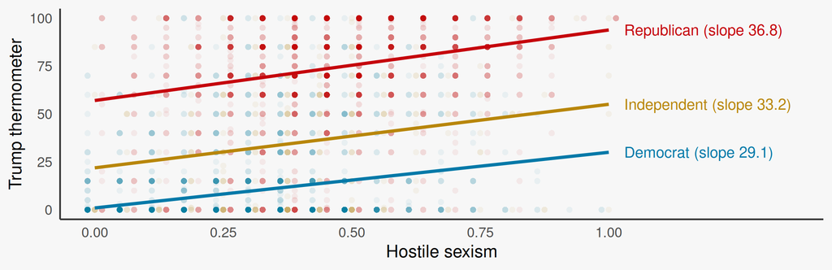

- Slopes actually aren’t that different!

## Interacting with education

- Does the slope on hostile sexism differ by **education**?
  - Let $X_i^{\text{Col}} = I(\text{college degree}_i)$ and add its product with $X_i$

  $$\hat{Y}_i = \hat{\beta}_0 + \hat{\beta}_1 X_i + \hat{\beta}_2 X_i^{\text{Col}} + \hat{\beta}_3 X_i X_i^{\text{Col}}$$
- Within each education group, the fit is a line in $X_i$ with its own intercept **and** slope

  $$\begin{aligned} \text{No college degree:} \quad & \hat{\beta}_0 + \hat{\beta}_1 X_i \\ \text{College degree:} \quad & (\hat{\beta}_0 + \hat{\beta}_2) + (\hat{\beta}_1 + \hat{\beta}_3) X_i \end{aligned}$$
- $\hat{\beta}_1$ is the slope among respondents **without** a degree (the baseline), and $\hat{\beta}_3$ is the **difference in slopes** for college graduates

## Interacting with education

```r
round(coef(lm(ft_trump ~ hostile_sexism * college, data = anes)), 2)
```

```
           (Intercept)         hostile_sexism                college hostile_sexism:college
                 15.42                  79.18                 -14.47                  20.43
```

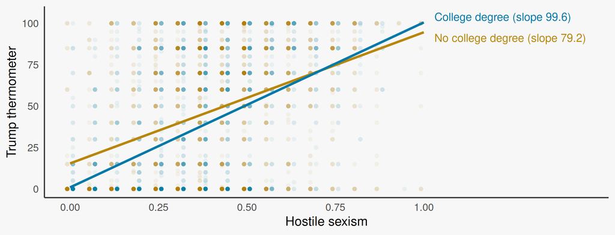

## A second continuous covariate

- **Racial resentment**: a three question measure from Kinder and Sanders (1996), also averaged and re-scaled to $[0, 1]$
  - Correlated with hostile sexism: $r = 0.50$
- With two continuous covariates, the fit is a **plane** over $(X_{i1}, X_{i2})$

  $$\hat{Y}_i = \hat{\beta}_0 + \hat{\beta}_1 X_{i1} + \hat{\beta}_2 X_{i2}$$

```r
round(coef(lm(ft_trump ~ hostile_sexism + racial_resentment, data = anes)), 2)
```

```
      (Intercept)    hostile_sexism racial_resentment
            -9.29             50.18             60.49
```

- After partialling **racial resentment** out of both the outcome and hostile sexism, the slope on hostile sexism is 50.2, also down from the unconditional 94.0

## In three dimensions

[interactive chart not shown]

## Interacting two continuous covariates

- A linear interaction with two **continuous** covariates adds the **product** of hostile sexism and racial resentment to the equation.

  $$\hat{Y}_i = \hat{\beta}_0 + \hat{\beta}_1 X_{i1} + \hat{\beta}_2 X_{i2} + \hat{\beta}_3 X_{i1} X_{i2}$$
- Holding $X_{i2}$ at a value $x_2$, we’re still estimating a **line** for $X_{i1}$, but its slope now **depends on** $x_2$

  $$\big[\hat{\beta}_0 + \hat{\beta}_1 (x_1 + 1) + \hat{\beta}_2 x_2 + \hat{\beta}_3 (x_1 + 1) x_2\big] - \big[\hat{\beta}_0 + \hat{\beta}_1 x_1 + \hat{\beta}_2 x_2 + \hat{\beta}_3 x_1 x_2\big] = \hat{\beta}_1 + \hat{\beta}_3 x_2$$
  - The **marginal ‘effect’** of $X_{i1}$ at $X_{i2} = x_2$. (be careful though, this is just a **slope** - we’re not yet making a causal claim).
  - $\hat{\beta}_1$ alone is the slope at $X_{i2} = 0$ - sometimes this is meaningful, sometimes it isn’t!

```r
round(coef(lm(ft_trump ~ hostile_sexism * racial_resentment, data = anes)), 2)
```

```
                     (Intercept)                   hostile_sexism                racial_resentment
                           -7.00                            41.42                            54.87
hostile_sexism:racial_resentment
                           17.33
```

## The interaction surface

[interactive chart not shown]

## Marginal effects plot

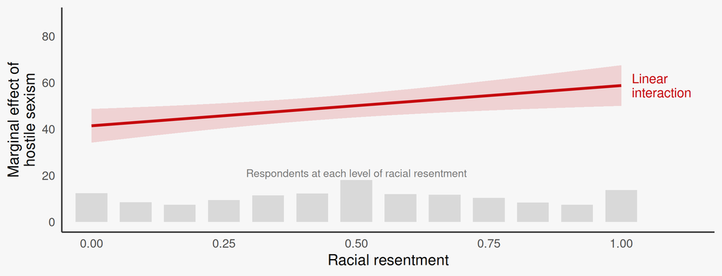

- The slope on hostile sexism rises from 41.4 at the lowest racial resentment to 58.8 at the highest, a **straight line** with slope $\hat{\beta}_3 = 17.3$
  - The band is a 95% confidence interval (using robust HC0 SEs)
- The gray bars show where the **data** are. Always plot the marginal effect against the distribution of the moderator

## Careful with linear interactions!

- $\hat{\beta}_1 + \hat{\beta}_3 x_2$ assumes the slope on $X_{i1}$ changes at a **constant rate** in $X_{i2}$
  - Where few respondents have a given $X_{i2}$ (**weak common support**), the predicted marginal effect relies heavily on the functional form assumption!
- Hainmueller et al. (2019) recommend a check that just uses **bins** of the effect modifier
  - Estimate separate slopes and intercepts **within each bin**
  - Think of what we did before: comparing the **noisy** binning approach with the **efficient** but potentially **biased** regression

## Binned marginal effects

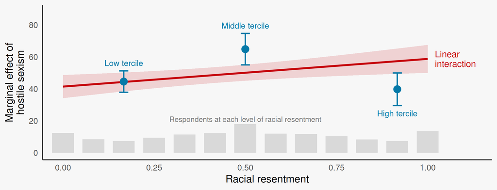

- The bins differ from the linear interaction results!
  - The slope is **steepest** in the middle tercile (64.9) and **flattest** in the top one (39.8), where the linear interaction puts its largest slope (57.3)
  - The linear interaction **forced** a monotone pattern onto a hump
- Likely because the thermometer is **bounded**:
  - Little room to move at either end, so the marginal “effects” get compressed at the tails.

## Consistency of OLS

- We’ve made a few regularity assumptions to ensure the **BLP** exists
- What do we need to make OLS **consistent** for the BLP?
  - Just i.i.d. sampling from the **target** population
- Write $Y_i$ in terms of the **projection error**, $Y_i = \mathbf{X}_i^\prime\boldsymbol{\beta} + e_i$, and substitute it into $\hat{\boldsymbol{\beta}}$

  $$\begin{aligned}
  \hat{\boldsymbol{\beta}} &= \left(\frac{1}{n}\sum_{i=1}^n \mathbf{X}_i\mathbf{X}_i^\prime\right)^{-1}\left(\frac{1}{n}\sum_{i=1}^n \mathbf{X}_i\big(\mathbf{X}_i^\prime\boldsymbol{\beta} + e_i\big)\right) \\
  &= \left(\frac{1}{n}\sum_{i=1}^n \mathbf{X}_i\mathbf{X}_i^\prime\right)^{-1}\left(\frac{1}{n}\sum_{i=1}^n \mathbf{X}_i\mathbf{X}_i^\prime\right)\boldsymbol{\beta} + \left(\frac{1}{n}\sum_{i=1}^n \mathbf{X}_i\mathbf{X}_i^\prime\right)^{-1}\left(\frac{1}{n}\sum_{i=1}^n \mathbf{X}_i e_i\right) \\
  &= \boldsymbol{\beta} + \left(\frac{1}{n}\sum_{i=1}^n \mathbf{X}_i\mathbf{X}_i^\prime\right)^{-1}\left(\frac{1}{n}\sum_{i=1}^n \mathbf{X}_i e_i\right)
  \end{aligned}$$

## Consistency of OLS

- By the **law of large numbers**, each sample mean converges to its population mean

  $$\frac{1}{n}\sum_{i=1}^n \mathbf{X}_i\mathbf{X}_i^\prime \xrightarrow{p} \mathbb{E}[\mathbf{X}_i\mathbf{X}_i^\prime] \qquad \frac{1}{n}\sum_{i=1}^n \mathbf{X}_i e_i \xrightarrow{p} \mathbb{E}[\mathbf{X}_i e_i] = \mathbf{0}$$
  - Last week we showed that the prediction errors are orthogonal to $X_i$ for the BLP **mechanically**
- The inverse is a **continuous** function, so by the **continuous mapping theorem**

  $$\hat{\boldsymbol{\beta}} \xrightarrow{p} \boldsymbol{\beta} + \big(\mathbb{E}[\mathbf{X}_i\mathbf{X}_i^\prime]\big)^{-1}\,\mathbf{0} = \boldsymbol{\beta}$$
- Really, we just need **an LLN** to apply to our sample plug-ins
  - So relaxations of i.i.d that still let us invoke LLN/CLT are fine
  - (e.g. clustered sampling, spatial correlation that dissipates over sufficient distances, etc…)

## Asymptotic normality of OLS

- For the sample mean, the **CLT** gave us $\sqrt{n}(\hat{\mu} - \mu) \xrightarrow{d} \mathcal{N}(0, \sigma^2)$. The same idea applies to $\hat{\boldsymbol{\beta}}$
- Multiply the decomposition by $\sqrt{n}$

  $$\sqrt{n}\big(\hat{\boldsymbol{\beta}} - \boldsymbol{\beta}\big) = \underbrace{\left(\frac{1}{n}\sum_{i=1}^n \mathbf{X}_i\mathbf{X}_i^\prime\right)^{-1}}_{\xrightarrow{p}\ \big(\mathbb{E}[\mathbf{X}_i\mathbf{X}_i^\prime]\big)^{-1}} \ \underbrace{\sqrt{n}\left(\frac{1}{n}\sum_{i=1}^n \mathbf{X}_i e_i - \mathbf{0}\right)}_{\xrightarrow{d}\ \mathcal{N}(\mathbf{0},\ \boldsymbol{\Omega})}$$
- A **multivariate CLT** applies to the sample mean of the i.i.d. $\mathbf{X}_ie_i$ random vectors and

  $$\boldsymbol{\Omega} = \Var(\mathbf{X}_i e_i) = \mathbb{E}[e_i^2\,\mathbf{X}_i\mathbf{X}_i^\prime]$$
- By **Slutsky’s theorem**

$\sqrt{n}\big(\hat{\boldsymbol{\beta}} - \boldsymbol{\beta}\big) \xrightarrow{d} \mathcal{N}\Big(\mathbf{0},\ \big(\mathbb{E}[\mathbf{X}_i\mathbf{X}_i^\prime]\big)^{-1}\,\boldsymbol{\Omega}\,\big(\mathbb{E}[\mathbf{X}_i\mathbf{X}_i^\prime]\big)^{-1}\Big)$

## The asymptotic variance

- Now let’s obtain $\Var(\hat{\boldsymbol{\beta}})$ - the **variance-covariance** matrix of the **sampling distribution** of $\hat{\boldsymbol{\beta}}$
  - For a $k \times k$ non-random matrix $\mathbf{A}$ and a random vector $\mathbf{Z}$, $\Var(\mathbf{A}\mathbf{Z}) = \mathbf{A}\,\Var(\mathbf{Z})\,\mathbf{A}^\prime$
    - This is the “matrix” equivalent of “squaring” a constant: $\Var(aZ) = a^2\Var(Z)$
- Applying this to $\hat{\boldsymbol{\beta}} - \boldsymbol{\beta} = \frac{1}{\sqrt{n}} \cdot \sqrt{n}\big(\hat{\boldsymbol{\beta}} - \boldsymbol{\beta}\big)$

  $$\Var(\hat{\boldsymbol{\beta}}) = \frac{1}{n}\Var\Bigg(\underbrace{\left(\frac{1}{n}\sum_{i=1}^n \mathbf{X}_i\mathbf{X}_i^\prime\right)^{-1}}_{\mathbf{A}\ \xrightarrow{p}\ \big(\mathbb{E}[\mathbf{X}_i\mathbf{X}_i^\prime]\big)^{-1}} \ \underbrace{\sqrt{n}\left(\frac{1}{n}\sum_{i=1}^n \mathbf{X}_i e_i - \mathbf{0}\right)}_{\mathbf{Z}\ \xrightarrow{d}\ \mathcal{N}(\mathbf{0},\ \boldsymbol{\Omega})}\Bigg)$$
- The result is a **sandwich**: two slices of **bread** around the **filling**

  $$\underbrace{\Var(\hat{\boldsymbol{\beta}})}_{k \times k} \approx \frac{1}{n} \underbrace{\big(\mathbb{E}[\mathbf{X}_i\mathbf{X}_i^\prime]\big)^{-1}}_{k \times k} \ \underbrace{\boldsymbol{\Omega}}_{k \times k} \ \underbrace{\big(\mathbb{E}[\mathbf{X}_i\mathbf{X}_i^\prime]\big)^{-1}}_{k \times k}$$

## The variance-covariance matrix

- Written out, the **variance-covariance matrix** of $\hat{\boldsymbol{\beta}}$ is

  $$\Var(\hat{\boldsymbol{\beta}}) = \begin{pmatrix} \Var(\hat{\beta}_0) & \Cov(\hat{\beta}_0, \hat{\beta}_1) & \cdots & \Cov(\hat{\beta}_0, \hat{\beta}_{k-1}) \\ \Cov(\hat{\beta}_1, \hat{\beta}_0) & \Var(\hat{\beta}_1) & \cdots & \Cov(\hat{\beta}_1, \hat{\beta}_{k-1}) \\ \vdots & \vdots & \ddots & \vdots \\ \Cov(\hat{\beta}_{k-1}, \hat{\beta}_0) & \Cov(\hat{\beta}_{k-1}, \hat{\beta}_1) & \cdots & \Var(\hat{\beta}_{k-1}) \end{pmatrix}$$
  - The **standard error** of $\hat{\beta}_j$ is the square root of the corresponding **diagonal** entry

## The filling

- $\mathbb{E}[\mathbf{X}_i e_i] = \mathbf{0}$, so $\boldsymbol{\Omega}$ is the expectation of an **outer product**

  $$\boldsymbol{\Omega} = \Var(\mathbf{X}_i e_i) = \mathbb{E}\big[(\mathbf{X}_i e_i)(\mathbf{X}_i e_i)^\prime\big] - \underbrace{\mathbb{E}[\mathbf{X}_i e_i]\,\mathbb{E}[\mathbf{X}_i e_i]^\prime}_{\mathbf{0}} = \mathbb{E}[e_i^2\,\mathbf{X}_i\mathbf{X}_i^\prime]$$
- Each respondent contributes $\mathbf{X}_i\mathbf{X}_i^\prime$ **weighted** by their squared error

  $$\small \underbrace{\mathbf{X}_i e_i}_{k \times 1} \quad \underbrace{(\mathbf{X}_i e_i)^\prime}_{1 \times k} = e_i^2 \begin{pmatrix} 1 \\ X_{i1} \\ \vdots \\ X_{i,k-1} \end{pmatrix} \begin{pmatrix} 1 & X_{i1} & \cdots & X_{i,k-1} \end{pmatrix} = \begin{pmatrix} e_i^2 & e_i^2 X_{i1} & \cdots & e_i^2 X_{i,k-1} \\ e_i^2 X_{i1} & e_i^2 X_{i1}^2 & \cdots & e_i^2 X_{i1} X_{i,k-1} \\ \vdots & \vdots & \ddots & \vdots \\ e_i^2 X_{i,k-1} & e_i^2 X_{i,k-1} X_{i1} & \cdots & e_i^2 X_{i,k-1}^2 \end{pmatrix}$$

## Estimating the variance

- **Plug-in principle** again: replace each expectation with a sample mean and each unobserved $e_i$ with its **residual** $\hat{e}_i = Y_i - \mathbf{X}_i^\prime\hat{\boldsymbol{\beta}}$

  $$\frac{1}{n}\sum_{i=1}^n \mathbf{X}_i\mathbf{X}_i^\prime = \frac{1}{n}\mathbf{X}^\prime\mathbf{X} \qquad \widehat{\boldsymbol{\Omega}} = \frac{1}{n}\sum_{i=1}^n \hat{e}_i^2\,\mathbf{X}_i\mathbf{X}_i^\prime$$
- Plug these into the sandwich (the $n$’s cancel)

  $$\begin{aligned}
  \widehat{\Var}(\hat{\boldsymbol{\beta}}) &= \frac{1}{n}\left(\frac{1}{n}\mathbf{X}^\prime\mathbf{X}\right)^{-1}\left(\frac{1}{n}\sum_{i=1}^n \hat{e}_i^2\,\mathbf{X}_i\mathbf{X}_i^\prime\right)\left(\frac{1}{n}\mathbf{X}^\prime\mathbf{X}\right)^{-1} \\
  &= (\mathbf{X}^\prime\mathbf{X})^{-1}\left(\sum_{i=1}^n \hat{e}_i^2\,\mathbf{X}_i\mathbf{X}_i^\prime\right)(\mathbf{X}^\prime\mathbf{X})^{-1}
  \end{aligned}$$
- This is the **heteroskedasticity-consistent** (HC0) or Eicker-Huber-White estimator - usually called **robust** standard errors

## Estimating the variance

- You’ll often see the filling written as an equivalent matrix product involving a $n \times n$ matrix $\widehat{\mathbf{D}}$

  $$\sum_{i=1}^n \hat{e}_i^2\,\mathbf{X}_i\mathbf{X}_i^\prime = \underbrace{\mathbf{X}^\prime}_{k \times n} \ \underbrace{\widehat{\mathbf{D}}}_{n \times n} \ \underbrace{\mathbf{X}}_{n \times k} = \begin{pmatrix} \mathbf{X}_1 & \mathbf{X}_2 & \cdots & \mathbf{X}_n \end{pmatrix} \begin{pmatrix} \hat{e}_1^2 & 0 & \cdots & 0 \\ 0 & \hat{e}_2^2 & \cdots & 0 \\ \vdots & \vdots & \ddots & \vdots \\ 0 & 0 & \cdots & \hat{e}_n^2 \end{pmatrix} \begin{pmatrix} \mathbf{X}_1^\prime \\ \mathbf{X}_2^\prime \\ \vdots \\ \mathbf{X}_n^\prime \end{pmatrix}$$
- Later on, we’ll connect this to the **variance-covariance matrix of the errors** in the classical regression setting
  - **Off-diagonals** are $0$: under **i.i.d. sampling**, $e_i$ and $e_j$ are independent
  - **Diagonals** $\sigma_i^2 = \mathbb{E}[e_i^2 \mid \mathbf{X}_i]$ can differ across respondents with different $\mathbf{X}_i$
  - The HC0 estimator plugs in $\hat{e}_i^2$ for each $\sigma_i^2$

## HC0 by hand

- The HC0 variance estimator is a $k \times k$ sandwich

  $$\underbrace{\widehat{\Var}(\hat{\boldsymbol{\beta}})}_{k \times k} = \underbrace{(\mathbf{X}^\prime\mathbf{X})^{-1}}_{k \times k} \ \underbrace{\mathbf{X}^\prime\widehat{\mathbf{D}}\mathbf{X}}_{k \times k} \ \underbrace{(\mathbf{X}^\prime\mathbf{X})^{-1}}_{k \times k}$$
- Let’s take a look at this with a complete regression with both attitude measures **and** the party dummies

```r
fit_full <- lm(ft_trump ~ hostile_sexism + racial_resentment + party, data = anes)

X <- model.matrix(fit_full)           # n x k: intercept, two attitudes, two party dummies
dim(X)
```

```
[1] 4562    5
```

```r
e_hat <- resid(fit_full)

bread <- solve(t(X) %*% X)            # (X'X)^{-1}, k x k
D <- diag(e_hat^2)                    # n x n, squared residuals on the diagonal
filling <- t(X) %*% D %*% X           # X'DX, k x k
V_hc0 <- bread %*% filling %*% bread  # k x k

round(sqrt(diag(V_hc0)), 3)           # standard errors: the square roots of the diagonal
```

```
      (Intercept)    hostile_sexism racial_resentment  partyIndependent   partyRepublican
            0.559             2.026             1.573             1.841             1.042
```

## HC0 with `sandwich`

- The `sandwich` package computes these for any `lm()` fit

```r
library(sandwich)
V_sw <- vcovHC(fit_full, type = "HC0")
round(sqrt(diag(V_sw)), 3)
```

```
      (Intercept)    hostile_sexism racial_resentment  partyIndependent   partyRepublican
            0.559             2.026             1.573             1.841             1.042
```

- Careful: the **default** in `vcovHC` is `type = "HC3"` which is a small-sample correction
  - “Robust” standard errors are **consistent** but not **unbiased** - in small samples they tend to be **too small**.
  - Many corrections proposed in the literature.
  - `HC1` rescales HC0 by $n/(n - k)$ (Stata’s `, robust`)
  - `HC2` and `HC3` rescale each $\hat{e}_i^2$ by how much observation $i$ pulls on its own fit

## Confidence intervals and tests

- Asymptotic normality lets us use the same approach to testing as before

  $$\frac{\hat{\beta}_j - \beta_j}{\widehat{SE}(\hat{\beta}_j)} \xrightarrow{d} \mathcal{N}(0, 1) \qquad \widehat{SE}(\hat{\beta}_j) = \sqrt{\big[\widehat{\Var}(\hat{\boldsymbol{\beta}})\big]_{jj}}$$
- 95% **confidence interval**: $\hat{\beta}_j \pm 1.96 \times \widehat{SE}(\hat{\beta}_j)$
- **Test** of $H_0: \beta_j = 0$: $t = \hat{\beta}_j / \widehat{SE}(\hat{\beta}_j)$, with two-sided p-value $2\big(1 - \Phi(|t|)\big)$

```r
b <- coef(fit_full)
se_hc0 <- sqrt(diag(V_sw))
t_hc0 <- b / se_hc0
cbind(round(cbind(estimate = b, se = se_hc0,
                  lower = b - qnorm(0.975) * se_hc0, upper = b + qnorm(0.975) * se_hc0,
                  t = t_hc0), 3),
      p = signif(2 * pnorm(-abs(t_hc0)), 3))
```

```
                  estimate    se  lower  upper      t        p
(Intercept)         -4.325 0.559 -5.422 -3.229 -7.734 1.04e-14
hostile_sexism      24.153 2.026 20.183 28.123 11.924 8.85e-33
racial_resentment   19.623 1.573 16.541 22.706 12.476 1.01e-35
partyIndependent    19.423 1.841 15.815 23.032 10.550 5.10e-26
partyRepublican     53.285 1.042 51.242 55.328 51.125 0.00e+00
```

## The sampling distribution of a line

## Standard errors for a bivariate regression

- With one regressor, the OLS slope is

  $$\hat{\beta}_1 = \frac{\sum_{i=1}^n (X_i - \bar{X})(Y_i - \bar{Y})}{\sum_{i=1}^n (X_i - \bar{X})^2} = \frac{\sum_{i=1}^n (X_i - \bar{X})\,Y_i}{\sum_{i=1}^n (X_i - \bar{X})^2}$$
- Substitute $Y_i = \beta_0 + \beta_1 X_i + e_i$. Because $\sum_i (X_i - \bar{X}) = 0$ and $\sum_i (X_i - \bar{X})X_i = \sum_i (X_i - \bar{X})^2$

  $$\hat{\beta}_1 = \beta_1 + \frac{\sum_{i=1}^n (X_i - \bar{X})\,e_i}{\sum_{i=1}^n (X_i - \bar{X})^2}$$

## Standard errors for a bivariate regression

- Divide the top and the bottom by $n$

  $$\hat{\beta}_1 - \beta_1 = \frac{\overbrace{\frac{1}{n}\sum_{i=1}^n (X_i - \bar{X})\,e_i}^{\approx\ \frac{1}{n}\sum_{i=1}^n (X_i - \mu_X)\,e_i}}{\underbrace{\frac{1}{n}\sum_{i=1}^n (X_i - \bar{X})^2}_{\xrightarrow{p}\ \Var(X_i)}}$$
- Since $\bar{X} \xrightarrow{p} \mu_X$, the numerator behaves like a sample mean of the i.i.d. $(X_i - \mu_X)e_i$, which have mean $0$ and variance $\mathbb{E}[(X_i - \mu_X)^2 e_i^2]$
- The variance of a sample mean of $n$ i.i.d. terms is $\frac{1}{n}$ times the variance of one term
  - …and the denominator is (approximately) the constant $\Var(X_i)$, so it comes out squared
- And we get the **sandwich** estimator in scalar form:

  $$\Var(\hat{\beta}_1) \approx \frac{1}{n}\,\frac{\overbrace{\mathbb{E}\big[(X_i - \mu_X)^2 e_i^2\big]}^{\text{filling}}}{\underbrace{\Var(X_i)^2}_{\text{bread}}}$$

## Standard errors for a bivariate regression

- **Plug-in**: replace the expectations with sample means and $e_i$ with $\hat{e}_i$ (the $n$’s cancel)

  $$\begin{aligned}
  \widehat{\Var}(\hat{\beta}_1) &= \frac{1}{n}\,\frac{\frac{1}{n}\sum_{i=1}^n (X_i - \bar{X})^2\,\hat{e}_i^2}{\Big(\frac{1}{n}\sum_{i=1}^n (X_i - \bar{X})^2\Big)^2} \\
  &= \frac{\sum_{i=1}^n (X_i - \bar{X})^2\,\hat{e}_i^2}{\Big(\sum_{i=1}^n (X_i - \bar{X})^2\Big)^2}
  \end{aligned}$$

  and $\widehat{SE}(\hat{\beta}_1) = \sqrt{\widehat{\Var}(\hat{\beta}_1)}$
- Our **standard error** for the slope is **smaller** when we have…
  - …a larger $n$
  - …more **spread** in $X_i$
  - …smaller errors, especially **far** from $\bar{X}$ since each $\hat{e}_i^2$ is weighted by $(X_i - \bar{X})^2$

## Uncertainty about $\hat{Y}$

- Given our standard errors for $\hat{\beta}_0$ and $\hat{\beta}_1$, we may want to know how precise our BLP estimate of $Y$ is at a given $x$

  $$\hat{Y}(x) = \hat{\beta}_0 + \hat{\beta}_1 x$$
- This is a sum of two random variables, so we need the full **variance-covariance matrix** of $\hat{\boldsymbol{\beta}}$

  $$\Var\bigg(\hat{Y}(x)\bigg) = \Var(\hat{\beta}_0) + x^2\,\Var(\hat{\beta}_1) + 2x\,\Cov(\hat{\beta}_0, \hat{\beta}_1)$$
  - Plug in the HC0 estimates of all three!
- To get the intuition for how the variance changes, re-write the line as: $\hat{Y}(x) = \bar{Y} + \hat{\beta}_1\,(x - \bar{X})$
  - At $\bar{X}$, we have uncertainty about $\bar{Y}$
  - **And** we have uncertainty about how the **slope**, which matters more as we move away from $\bar{X}$
  - So the sampling variance is smallest near $\bar{X}$ and grows as we move away from it, giving a **“bowtie”** shape to the confidence intervals.

## Confidence interval for the regression line

```r
# HC0 vcov of the intercept and slope
V <- vcovHC(fit_hs, type = "HC0")
V
```

```
               (Intercept) hostile_sexism
(Intercept)      0.6418807      -1.362200
hostile_sexism  -1.3622003       4.614875
```

```r
grid <- seq(0, 1, by = 0.01)
se_fit <- sqrt(V[1, 1] + grid^2 * V[2, 2] +
                2 * grid * V[1, 2])

line_ci <- tibble(x = grid,
                  fit = b_hs[1] + b_hs[2] * grid,
                  lower = fit - 1.96 * se_fit,
                  upper = fit + 1.96 * se_fit)
head(line_ci, 3)
```

```
# A tibble: 3 × 4
      x   fit lower upper
  <dbl> <dbl> <dbl> <dbl>
1  0     6.23  4.66  7.80
2  0.01  7.17  5.63  8.71
3  0.02  8.11  6.61  9.61
```

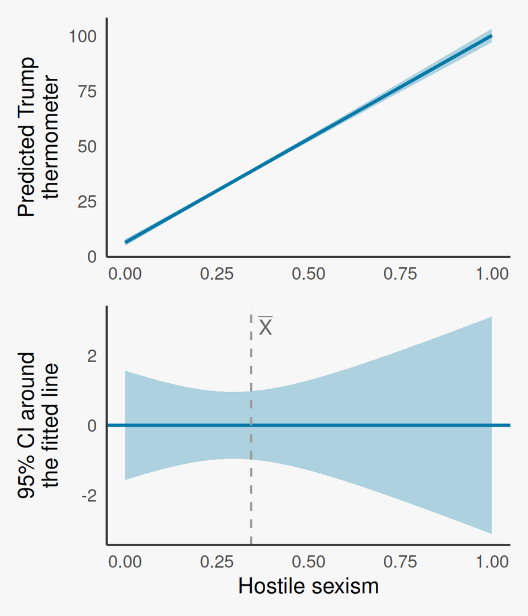

## Comparing robust SEs with `lm()` defaults

- `coeftest()` from `lmtest` will implement the tests with whatever variance covariance matrix we want to give it

```r
library(lmtest)
coeftest(fit_full)                                           # lm() defaults
```

```
t test of coefficients:

                  Estimate Std. Error t value  Pr(>|t|)
(Intercept)       -4.32538    0.70955 -6.0959 1.178e-09 ***
hostile_sexism    24.15327    1.85536 13.0181 < 2.2e-16 ***
racial_resentment 19.62334    1.41061 13.9112 < 2.2e-16 ***
partyIndependent  19.42301    1.41708 13.7064 < 2.2e-16 ***
partyRepublican   53.28474    0.85917 62.0190 < 2.2e-16 ***
---
Signif. codes:  0 '***' 0.001 '**' 0.01 '*' 0.05 '.' 0.1 ' ' 1
```

```r
coeftest(fit_full, vcov = vcovHC(fit_full, type = "HC0"))    # robust (HC0)
```

```
t test of coefficients:

                  Estimate Std. Error t value  Pr(>|t|)
(Intercept)       -4.32538    0.55927  -7.734 1.274e-14 ***
hostile_sexism    24.15327    2.02556  11.924 < 2.2e-16 ***
racial_resentment 19.62334    1.57288  12.476 < 2.2e-16 ***
partyIndependent  19.42301    1.84110  10.550 < 2.2e-16 ***
partyRepublican   53.28474    1.04225  51.125 < 2.2e-16 ***
---
Signif. codes:  0 '***' 0.001 '**' 0.01 '*' 0.05 '.' 0.1 ' ' 1
```

## Comparing robust SEs with `lm()` defaults

|  | `lm()` default (1) | Robust (HC0) (2) |
| --- | --- | --- |
| Intercept | −4.33*** | −4.33*** |
|  | (0.71) | (0.56) |
| Hostile sexism | 24.15*** | 24.15*** |
|  | (1.86) | (2.03) |
| Racial resentment | 19.62*** | 19.62*** |
|  | (1.41) | (1.57) |
| Independent | 19.42*** | 19.42*** |
|  | (1.42) | (1.84) |
| Republican | 53.28*** | 53.28*** |
|  | (0.86) | (1.04) |
| N | 4,562 | 4,562 |
| R² | 0.68 | 0.68 |

Outcome: Trump thermometer. Democrats are the omitted party baseline. Standard errors in parentheses. Two-sided tests of H₀: β<sub>j</sub> = 0: * p < 0.05, ** p < 0.01, *** p < 0.001.

- The **estimates** are identical. Only the **standard errors** change
- The robust SEs are **larger** for every slope
  - 30% larger for the Independent dummy
- Why are they larger?

*T-stat looks too good.*  
*Use robust standard errors—*  
*significance gone.*

— Keisuke Hirano

## Homoskedasticity

- The **classical** OLS model adds an assumption about the errors: **homoskedasticity**

  $$\mathbb{E}[e_i^2 \mid \mathbf{X}_i] = \sigma^2$$
  - The variance of the errors is **constant** at every value of the covariates
- Under homoskedasticity, the filling simplifies by the **law of iterated expectations**

  $$\boldsymbol{\Omega} = \mathbb{E}[e_i^2\,\mathbf{X}_i\mathbf{X}_i^\prime] = \mathbb{E}\big[\mathbb{E}[e_i^2 \mid \mathbf{X}_i]\,\mathbf{X}_i\mathbf{X}_i^\prime\big] = \sigma^2\,\mathbb{E}[\mathbf{X}_i\mathbf{X}_i^\prime]$$
- And the sandwich reduces to…

  $$\Var(\hat{\boldsymbol{\beta}}) \approx \frac{1}{n}\big(\mathbb{E}[\mathbf{X}_i\mathbf{X}_i^\prime]\big)^{-1}\,\sigma^2\mathbb{E}[\mathbf{X}_i\mathbf{X}_i^\prime]\,\big(\mathbb{E}[\mathbf{X}_i\mathbf{X}_i^\prime]\big)^{-1} = \frac{\sigma^2}{n}\big(\mathbb{E}[\mathbf{X}_i\mathbf{X}_i^\prime]\big)^{-1}$$

  $$\Var(\hat{\boldsymbol{\beta}}) \approx \frac{1}{n}\sigma^2\left(\frac{1}{n}\mathbf{X}^\prime\mathbf{X}\right)^{-1} = \sigma^2(\mathbf{X}^\prime\mathbf{X})^{-1}$$

## Is homoskedasticity plausible?

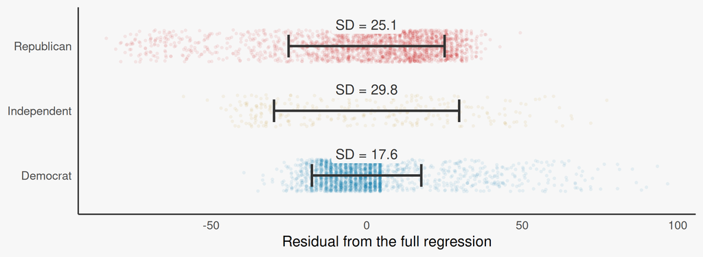

- No! The residuals are far more **spread out** for Independents and Republicans than for Democrats
  - What we’d expect for a bounded thermometer: 75% of Democrats rate Trump at exactly **0**
  - Can’t go any lower!

## Estimating $\sigma^2$

- A natural plug-in for $\sigma^2$ is $\frac{1}{n}\sum_{i=1}^n \hat{e}_i^2$.
  - But like the plug-in sample variance, it is **biased** downward: OLS picks $\hat{\boldsymbol{\beta}}$ to make the residuals small **in this sample**
- The **unbiased** estimator divides by $n - k$, the number of observations minus the number of coefficients

  $$\hat{\sigma}^2 = \frac{1}{n - k}\sum_{i=1}^n \hat{e}_i^2$$
- Related to our earlier results for the unbiased population variance estimator
  - There we divided by $n-1$
  - Here since each estimated coefficient “uses up” one **degree of freedom**, we divide by $n-k$.
- The **classical** OLS variance estimator is therefore

  $$\widehat{\Var}(\hat{\boldsymbol{\beta}}) = \hat{\sigma}^2(\mathbf{X}^\prime\mathbf{X})^{-1}$$
- Default for `summary(lm())`

## Robust or classical?

- **HC** standard errors are consistent whether or not the errors are homoskedastic
  - **Classical** standard errors are only consistent under homoskedasticity
- If homoskedasticity **does** hold, the classical estimator is more precise.
  - But it’s rarely a credible assumption!
- In practice: **default** to robust standard errors
  - In 813, we’ll talk more about the `HC2` correction (default in `lm_robust()` in the `estimatr` package).
  - “Agnostic” regression

## The classical linear model

- Many textbooks start from a much stronger set of assumptions. Conditional on the $n \times k$ matrix $\mathbf{X}$
  1. **Linearity**: $\mathbf{Y} = \mathbf{X}\boldsymbol{\beta} + \mathbf{e}$ with $\mathbb{E}[\mathbf{e} \mid \mathbf{X}] = \mathbf{0}$. The CEF **is** linear
  2. **Full rank**: $\mathbf{X}^\prime\mathbf{X}$ is invertible
  3. **Spherical errors**: $\Var(\mathbf{e} \mid \mathbf{X}) = \sigma^2\mathbf{I}_n$. Homoskedastic and uncorrelated across observations
  4. (Sometimes) **Normality**: $\mathbf{e} \mid \mathbf{X} \sim \mathcal{N}(\mathbf{0}, \sigma^2\mathbf{I}_n)$
- The benefit of this is that we get **exact** finite-sample results instead of asymptotic approximations
  - Under 1-3, OLS is **unbiased** and its variance is **exactly** the classical formula

  $$\mathbb{E}[\hat{\boldsymbol{\beta}} \mid \mathbf{X}] = \boldsymbol{\beta} \qquad \Var(\hat{\boldsymbol{\beta}} \mid \mathbf{X}) = (\mathbf{X}^\prime\mathbf{X})^{-1}\mathbf{X}^\prime\,\underbrace{\Var(\mathbf{e} \mid \mathbf{X})}_{\sigma^2\mathbf{I}_n}\,\mathbf{X}(\mathbf{X}^\prime\mathbf{X})^{-1} = \sigma^2(\mathbf{X}^\prime\mathbf{X})^{-1}$$
- Our “agnostic” approach so far needed only i.i.d. sampling and the regularity conditions
  - OLS estimates the **BLP**, whatever the CEF looks like, and the robust variance is valid for asymptotic inference on the **BLP**

## SEs and assumptions about the error variances

- With a linear CEF, the “filling” of the sandwich variance can be written in terms of the **variance-covariance matrix of the errors** $\boldsymbol{\Sigma} = \Var(\mathbf{e} \mid \mathbf{X})$

  $$\Var(\hat{\boldsymbol{\beta}} \mid \mathbf{X}) = (\mathbf{X}^\prime\mathbf{X})^{-1}\,\mathbf{X}^\prime\boldsymbol{\Sigma}\mathbf{X}\,(\mathbf{X}^\prime\mathbf{X})^{-1}$$
- Each standard error estimator assumes a different $\boldsymbol{\Sigma}$

**Homoskedastic**

$$\small \begin{pmatrix} \sigma^2 & 0 & \cdots & 0 \\ 0 & \sigma^2 & \cdots & 0 \\ \vdots & \vdots & \ddots & \vdots \\ 0 & 0 & \cdots & \sigma^2 \end{pmatrix}$$

- Constant variance + no cross-unit covariance
- Plug in $\hat{\sigma}^2$: **classical**

**Heteroskedastic**

$$\small \begin{pmatrix} \sigma_1^2 & 0 & \cdots & 0 \\ 0 & \sigma_2^2 & \cdots & 0 \\ \vdots & \vdots & \ddots & \vdots \\ 0 & 0 & \cdots & \sigma_n^2 \end{pmatrix}$$

- Non-constant variance + no cross-unit covariance
- Plug in $\hat{e}_i^2$: **HC**

**Clustered**

$$\small \left(\begin{array}{ccc|ccc|c} \sigma_1^2 & \sigma_{12} & \cdots & 0 & 0 & \cdots & \cdots \\ \sigma_{12} & \sigma_2^2 & \cdots & 0 & 0 & \cdots & \cdots \\ \vdots & \vdots & \ddots & \vdots & \vdots & & \\ \hline 0 & 0 & \cdots & \sigma_j^2 & \sigma_{jk} & \cdots & \cdots \\ 0 & 0 & \cdots & \sigma_{jk} & \sigma_k^2 & \cdots & \cdots \\ \vdots & \vdots & & \vdots & \vdots & \ddots & \\ \hline \vdots & \vdots & & \vdots & \vdots & & \ddots \end{array}\right)$$

- **Arbitrary** correlation within clusters but none **across**
- Plug in $\hat{e}_i\hat{e}_j$ within clusters: **cluster-robust**

## The Gauss-Markov theorem

- Under assumptions 1-3, OLS is the **B**est **L**inear **U**nbiased **E**stimator (**BLUE**)
  - **Linear**: $\tilde{\boldsymbol{\beta}} = \mathbf{C}\mathbf{Y}$ for some $k \times n$ matrix $\mathbf{C}$ that depends only on $\mathbf{X}$. OLS has $\mathbf{C} = (\mathbf{X}^\prime\mathbf{X})^{-1}\mathbf{X}^\prime$
  - **Unbiased**: $\mathbb{E}[\tilde{\boldsymbol{\beta}} \mid \mathbf{X}] = \mathbf{C}\mathbf{X}\boldsymbol{\beta} = \boldsymbol{\beta}$ for every $\boldsymbol{\beta}$, which requires $\mathbf{C}\mathbf{X} = \mathbf{I}_k$
  - **Best**: no other linear unbiased estimator has a smaller variance for any coefficient (or linear combination of coefficients)
- **Proof sketch**: write an alternative estimator that deviates from OLS: $\mathbf{C} = (\mathbf{X}^\prime\mathbf{X})^{-1}\mathbf{X}^\prime + \mathbf{D}$.
  - Unbiasedness requires $\mathbf{D}\mathbf{X} = \mathbf{0}$, so the cross terms drop out

  $$\small \Var(\tilde{\boldsymbol{\beta}} \mid \mathbf{X}) = \sigma^2\mathbf{C}\mathbf{C}^\prime = \sigma^2\big[(\mathbf{X}^\prime\mathbf{X})^{-1} + \underbrace{(\mathbf{X}^\prime\mathbf{X})^{-1}\mathbf{X}^\prime\mathbf{D}^\prime}_{\mathbf{0}} + \underbrace{\mathbf{D}\mathbf{X}(\mathbf{X}^\prime\mathbf{X})^{-1}}_{\mathbf{0}} + \mathbf{D}\mathbf{D}^\prime\big] = \Var(\hat{\boldsymbol{\beta}} \mid \mathbf{X}) + \sigma^2\mathbf{D}\mathbf{D}^\prime$$
  - The $j$th diagonal entry of $\mathbf{D}\mathbf{D}^\prime$ is a sum of squares, $\sum_i D_{ji}^2 \geq 0$, so every coefficient’s variance can only go **up**

## What BLUE does and doesn’t buy us

- “Best” only among estimators that are **linear** in $\mathbf{Y}$ **and** **unbiased**
  - A **biased** estimator can have a lower mean squared error (e.g. a penalized regression)
- It depends on **homoskedasticity**:
  - **Weighted** least squares, which down-weights the noisier observations, can do better if we know the form of the heteroskedasticity
  - And the classical standard errors are **wrong**
- It needs a **linear CEF** for unbiasedness
  - Without it, OLS is still consistent for the **BLP**, but the finite-sample results no longer hold

## Hierarchy of assumptions

|  | Compute \(\hat{\boldsymbol{\beta}}\) | Consistent for the BLP | Asymptotic inference on the BLP(robust SEs) | Unbiased for the CEF | BLUE(classical SEs) | Exact finite-sample inference(\(t_{n-k}\)) |
| --- | --- | --- | --- | --- | --- | --- |
| No perfect collinearity | ✓ | ✓ | ✓ | ✓ | ✓ | ✓ |
| i.i.d. sampling + regularity conditions |  | ✓ | ✓ | ✓ | ✓ | ✓ |
| Linear CEF, \(\mathbb{E}[e_i \mid \mathbf{X}_i] = 0\) |  |  |  | ✓ | ✓ | ✓ |
| Homoskedasticity, \(\Var(e_i \mid \mathbf{X}_i) = \sigma^2\) |  |  |  |  | ✓ | ✓ |
| Normal errors |  |  |  |  |  | ✓ |

- **Very little** gets us the BLP and valid (asymptotic) inference on it: i.i.d. sampling, robust standard errors and a CLT
- Saying anything about the **CEF** itself requires it to be linear (in whatever $\mathbf{X}$ we provide).
- Homoskedasticity and normality get **efficiency** and **exact** small-sample inference, but they’re rarely credible

## Next week

- Wrapping up **inference** for regression
  - **Wald** tests of several coefficients at once
- More regression mechanics
  - Regression as a **linear smoother** of $\mathbf{Y}$
  - Regression as a kind of **“weighting”** estimator
  - Leverage and influential observations
  - Diagnosing your regression
- **Problem Set 5** due Tuesday, November 17
- **Second Midterm Exam** on Wednesday, November 18

## References

Hainmueller, Jens, Jonathan Mummolo, and Yiqing Xu. 2019. “How Much Should We Trust Estimates from Multiplicative Interaction Models? Simple Tools to Improve Empirical Practice.” *Political Analysis* 27 (2): 163–92. https://doi.org/10.1017/pan.2018.46.

Kinder, Donald R., and Lynn M. Sanders. 1996. *Divided by Color: Racial Politics and Democratic Ideals*. University of Chicago Press.